# Cleaning the FDIC BankFind Data

Last updated: 2024-03-01

## Preliminary Work: Install/Load Packages

To try and ensure that this R Notebook will run successfully, we’ll use the [renv package](https://cran.r-project.org/web/packages/renv/index.html) to create a project-specific library of packages. This will allow us to install the packages that we need for this project without affecting any other projects that we may be working on. Additionally, the project library will track the specific versions of the dependency packages so that any updates to those packages will not break this project.

The code chunk below will first install the renv package if it is not already installed. Then we will load the package. Next, we’ll use the `restore()` function to install any packages listed in the renv.lock file. Once these packages are installed, we can load them into the R session using the `library()` commands. Below the code chunk, we’ll list out the packages that will be used in the project demo. And if you run into any trouble using renv, then you can use the second code chunk below and that should be an even more reliable approach to install the required packages.

```r
# Install renv package if not already installed
if(!"renv" %in% installed.packages()[,"Package"]) install.packages("renv")
# Load renv package
library(renv)
# Use restore() to install any packages listed in the renv.lock file
renv::restore(clean=TRUE, lockfile="../renv.lock")
y
# Load in the packages
library(readr)
library(curl)
library(dplyr)
library(ggplot2)
library(fst)
library(xts)
library(rmarkdown)
```

- The [readr package](https://cran.r-project.org/package=readr) is a common package for reading in data files. After installing, the RStudio Environment tab will have a new option to import data sets that uses this package. It will even generate the R code for you to copy and paste into your script.
- The [dplyr package](https://cran.r-project.org/package=dplyr) package enables additional functionality for transforming data frames.
- The [ggplot2 package](https://cran.r-project.org/package=ggplot2) lets us generate nice graphics to visualize the data.
- The [fst package](https://cran.r-project.org/package=fst) is a fast and efficient way to save and load data frames. It is especially useful for large datasets.
- The [xts package](https://cran.r-project.org/package=xts) allows for some additional time series functionality.
- The [rmarkdown package](https://cran.r-project.org/package=rmarkdown) is used to generate this R Notebook.

Since the rmarkdown functionality is built into RStudio, this one is automatically loaded when we open the RStudio. So no need to use the `library()` function for this one. Another observation to make about the code chunk above is that it is labeled as ‘setup’, which is a special name, which the R Notebook will recognize and automatically run prior to running any other code chunk. This is useful for loading in packages and setting up other global options that will be used throughout the notebook.

Then if you wish to try and update the versions of the various R packages in the lock file, you can use the `renv::update()` function to update the packages in the project library. However, it is possible that these updates could break the code in this notebook. If so, you may need to adapt the code to work with the updated packages.

My recommendation is to first run through the code using the versions of the packages in the lock file. Then if you want to try and update the packages, you can do so and then run through the code again to see if it still works. If not, you can always revert back to the lock file versions using the `renv::restore()` function.

If you update the packages and get everything working successfully, then you can update the lock file using the `renv::snapshot()` function. This will update the lock file with the versions of the packages that are currently installed in the project library. Then you can commit the updated lock file to the repository so that others can use the updated versions of the packages.

### Alternative Package Installation Code

If you run into any trouble using renv in the code chunk above, then you can use the code chunk below to install the required packages for this analysis. This method will first check if you have already installed the packages. If any are missing, it will then install them. Then it will load the packages into the R session. A potential flaw in this approach compared to using renv is that it will simply install the latest versions of the packages, which could potentially break some of the code in this notebook if any of the updates aren’t backwards compatible.

As long as you have downloaded the entire project repository, the renv chunk above will likely be managing the packages. Thus, the `eval=FALSE` option is used to prevent this chunk from running unless manually executed. So if you only downloaded this one Rmd file, this code chunk should take care of installing the packages for you.

```r
# Create list of packages needed for this exercise
list.of.packages = c("readr","curl","dplyr","ggplot2","fst","xts","rmarkdown")
# Check if any have not yet been installed
new.packages = list.of.packages[!(list.of.packages %in% installed.packages()[,"Package"])]
# If any need to be installed, install them
if(length(new.packages)) install.packages(new.packages)
# Load in the packages
library(readr)
library(curl)
library(dplyr)
library(ggplot2)
library(fst)
library(xts)
library(rmarkdown)
```

## Data Import and Cleaning

Now if you go to the [FDIC BankFind API](https://banks.data.fdic.gov/docs/) website and right click on the link for the [Institutions (CSV format)](https://s3-us-gov-west-1.amazonaws.com/cg-2e5c99a6-e282-42bf-9844-35f5430338a5/downloads/institutions.csv) file, then you can copy the link address. Let’s paste that below:

```r
institutionsurl = "https://s3-us-gov-west-1.amazonaws.com/cg-2e5c99a6-e282-42bf-9844-35f5430338a5/downloads/institutions.csv"
```

From this, we can see that the FDIC is using Amazon Web Services to store/host their datasets. I’m not sure if the “cg-2e5c99a6-e282-42bf-9844-35f5430338a5” portion of the url is linked to the version of the dataset in regard to updates. If that changes when there is an update, then a more formal API call may be necessary to incorporate updates smoothly.

Next, bring this over to RStudio, and in the Environment panel, click Import Dataset and select From Text (readr). This will open an interactive window where you can paste the url into the top box. Then after clicking Update, this will pull the csv file from the url and display a preview along with a suite of options for doing some data cleaning. Some cleaning techniques, such as factor (categorical) variables, are more easily applied after importing the data. But many other cleaning/formatting steps can be done from this interactive window. *Being able to efficiently use this tool can save lots of time since it keeps track of the cleaning steps that you take and auto-generates the R code in the bottom-right that you can copy over to get started with a particular dataset.*

But before we get too far into the cleaning process, let’s first do a quick aside to set up an examination of the impact of this data cleaning on the required storage space for the data. If you just want to get on with the analysis, you can skip over this next subsection.

### Raw Data

```r
institutions = read_csv(institutionsurl)
```

```
Warning: One or more parsing issues, call `problems()` on your data frame for details, e.g.:
  dat <- vroom(...)
  problems(dat)Rows: 27824 Columns: 142── Column specification ────────────────────────────────────────────────────────────────────────────────
Delimiter: ","
chr  (52): STNAME, ADDRESS, BKCLASS, CHRTAGNT, CONSERVE, CITY, CMSA, COUNTY, DATEUPDT, EFFDATE, ENDE...
dbl  (74): CERT, DOCKET, ACTIVE, ASSET, CHANGEC1, CHANGEC2, CHANGEC3, CHANGEC4, CHANGEC5, CHANGEC6, ...
lgl  (14): CHANGEC8, CHANGEC9, CHANGEC10, CHANGEC11, CHANGEC12, CHANGEC13, CHANGEC14, CHANGEC15, REG...
date  (2): CFPBEFFDTE, CFPBENDDTE
ℹ Use `spec()` to retrieve the full column specification for this data.
ℹ Specify the column types or set `show_col_types = FALSE` to quiet this message.
```

```r
problems()
```

| row | col | expected | actual | file |
| --- | --- | --- | --- | --- |
| 4257 | 103 | 1/0/T/F/TRUE/FALSE | The Guaranty Bank |  |
| 4353 | 103 | 1/0/T/F/TRUE/FALSE | Merrill |  |
| 4353 | 104 | 1/0/T/F/TRUE/FALSE | Merrill Lynch |  |
| 4530 | 97 | 1/0/T/F/TRUE/FALSE | www.bankohiocounty.com |  |
| 4695 | 97 | 1/0/T/F/TRUE/FALSE | www.buildbuyrefi.com |  |
| 4695 | 98 | 1/0/T/F/TRUE/FALSE | usadanationwide.com |  |
| 4817 | 103 | 1/0/T/F/TRUE/FALSE | YNB Peoples |  |
| 4852 | 97 | 1/0/T/F/TRUE/FALSE | www.banksanjuans.com |  |
| 4852 | 98 | 1/0/T/F/TRUE/FALSE | www.northcascadesbank.com |  |
| 4852 | 103 | 1/0/T/F/TRUE/FALSE | Mountain west Bank |  |

[output cut: 86 more lines]

Even though there are some errors with the import here, let’s save this basic attempt as our initial raw data for future comparisons. As another point of comparison, let’s use three different formats for saving the data. The first, csv, is the same format as the data was provided in and is very portable. The Rds format is R-specific and generally uses minimal storage space; however, it can be slower to load large datasets compared to the fst format. This last format uses a non-native R package `fst` and is optimized for working with large datasets (this one isn’t that large).

```r
dir.create("Data/", showWarnings=FALSE)
dir.create("Data/Raw/", showWarnings=FALSE)
write.csv(institutions,"Data/Raw/institutions.csv")
saveRDS(institutions,"Data/Raw/institutions.Rds")
write.fst(institutions,"Data/Raw/institutions.fst")
```

```
fstcore package v0.9.18
(OpenMP detected, using 24 threads)
```

### Cleaning and Formatting

Using the above mentioned Import Dataset UI, let’s clean up the formatting to at least successfully import all of the variables. The code chunk below is the result of my manual cleaning of the Institutions CSV file with one exception. I replaced the full url in the auto-generated code with the one we saved earlier to `institutionsurl`. The cleaning steps that I took in the interactive window were switching the date variables to date formats (except for the CFPB dates, which were in a different format and had year 9999) and fixing the formatting several other variables that were identified from the above warning output. *I strongly recommend opening the [Institutions Definitions (CSV format)](https://banks.data.fdic.gov/docs/institutions_definitions.csv) file in Excel to help understand the dataset and cleaning process.*

```r
institutions = read_csv(institutionsurl,
    col_types = cols(DATEUPDT = col_date(format = "%m/%d/%Y"),
        EFFDATE = col_date(format = "%m/%d/%Y"),
        ENDEFYMD = col_date(format = "%m/%d/%Y"),
        ESTYMD = col_date(format = "%m/%d/%Y"),
        INSDATE = col_date(format = "%m/%d/%Y"),
        PROCDATE = col_date(format = "%m/%d/%Y"),
        # REPDTE = col_date(format = "%m/%d/%Y"),
        # RISDATE = col_date(format = "%m/%d/%Y"),
        # RUNDATE = col_date(format = "%m/%d/%Y"),
        # PROCDATE = col_date(format = "%m/%d/%Y"),
        # REPDTE = col_date(format = "%m/%d/%Y"),
        CHANGEC7 = col_character(), CHANGEC8 = col_character(),
        CHANGEC9 = col_character(), CHANGEC10 = col_character(),
        CHANGEC11 = col_character(), CHANGEC12 = col_character(),
        CHANGEC13 = col_character(), CHANGEC14 = col_character(),
        CHANGEC15 = col_character(),
        CFPBEFFDTE = col_character(), CFPBENDDTE = col_character(),
        REGAGENT2 = col_character(), TE02N528 = col_character(),
        TE03N528 = col_character(), TE04N528 = col_character(),
        TE05N528 = col_character(), TE06N528 = col_character(),
        TE07N528 = col_character(), TE08N528 = col_character(),
        TE09N528 = col_character(), TE10N528 = col_character(),
        TE02N529 = col_character(), TE03N529 = col_character(),
        TE04N529 = col_character(), TE05N529 = col_character(),
        TE06N529 = col_character(), CERTCONS = col_character()))
```

```r
dir.create("Data/Interm/", showWarnings=FALSE)
write.csv(institutions,"Data/Interm/institutions.csv")
saveRDS(institutions,"Data/Interm/institutions.Rds")
write.fst(institutions,"Data/Interm/institutions.fst")
file.size("Data/Raw/institutions.csv")
```

```
[1] 23167190
```

```r
file.size("Data/Interm/institutions.csv")
```

```
[1] 22946374
```

```r
file.size("Data/Interm/institutions.csv")/file.size("Data/Raw/institutions.csv")
```

```
[1] 0.9904686
```

```r
file.size("Data/Raw/institutions.Rds")
```

```
[1] 4515005
```

```r
file.size("Data/Interm/institutions.Rds")
```

```
[1] 4452474
```

```r
file.size("Data/Interm/institutions.Rds")/file.size("Data/Raw/institutions.Rds")
```

```
[1] 0.9861504
```

```r
file.size("Data/Raw/institutions.fst")
```

```
[1] 14670970
```

```r
file.size("Data/Interm/institutions.fst")
```

```
[1] 14854497
```

```r
file.size("Data/Interm/institutions.fst")/file.size("Data/Raw/institutions.fst")
```

```
[1] 1.01251
```

Now let’s finish cleaning up the formatting of the other variables. Again, these steps are primarily derived from reading through the [Institutions Definitions](https://banks.data.fdic.gov/docs/institutions_definitions.csv) file. So be sure to refer back to that frequently as you run through these steps.

#### Logical (Binary) Variables

When there are only two categories in a variable, these can be even more efficiently stored by a logical format.

```r
institutions$ACTIVE = as.logical(institutions$ACTIVE)
institutions$CONSERVE = as.logical(institutions$CONSERVE)
institutions$DENOVO = as.logical(institutions$DENOVO)
institutions$FEDCHRTR = as.logical(institutions$FEDCHRTR)
institutions$IBA = as.logical(institutions$IBA)
institutions$INACTIVE = as.logical(institutions$INACTIVE)
institutions$INSTCRCD = as.logical(institutions$INSTCRCD)
institutions$INSBIF = as.logical(institutions$INSBIF)
institutions$INSCOML = as.logical(institutions$INSCOML)
institutions$INSDIF = as.logical(institutions$INSDIF)
institutions$INSFDIC = as.logical(institutions$INSFDIC)
institutions$INSSAIF = as.logical(institutions$INSSAIF)
institutions$INSSAVE = as.logical(institutions$INSSAVE)
institutions$OAKAR = as.logical(institutions$OAKAR)
```

#### Factor Variables

Now that we have all the data loaded into memory, we can reformat our categorical variables into factors so that they are more efficiently stored and analyzed by R. Some categorical variables are fairly straightforward (e.g. State Name, City, etc) and just require a simple conversion using `as.factor()`. Those are all reformatted here.

```r
institutions$STNAME = as.factor(institutions$STNAME)
institutions$CHRTAGNT = as.factor(institutions$CHRTAGNT)
institutions$CITY = as.factor(institutions$CITY)
institutions$CMSA = as.factor(institutions$CMSA)
institutions$COUNTY = as.factor(institutions$COUNTY)
institutions$FDICDBS = as.factor(institutions$FDICDBS)
institutions$FDICREGN = as.factor(institutions$FDICREGN)
institutions$FDICSUPV = as.factor(institutions$FDICSUPV)
institutions$FLDOFF = as.factor(institutions$FLDOFF)
institutions$INSAGNT1 = as.factor(institutions$INSAGNT1)
institutions$INSAGNT2 = as.factor(institutions$INSAGNT2)
institutions$MSA = as.factor(institutions$MSA)
institutions$QBPRCOML = as.factor(institutions$QBPRCOML) # Numeric codes, but definitions has no labels
institutions$REGAGNT = as.factor(institutions$REGAGNT)
```

#### Encoded Factor Variables

Some other categorical variables in the dataset are encoded in the csv file and have more detailed descriptions in the Institutions Definitions file. One feature of factor variables in R is that each level (category) can have a label in the metadata that is integrated into many other R packages. Below, we’ll demonstrate how these labels can be used to provide more detail in plots while still being stored efficiently and used appropriately in statistical analysis.

##### BKCLASS

From the Institutions Definitions file for the BKCLASS variable:

“A classification code assigned by the FDIC based on the institution’s charter type (commercial bank or savings institution), charter agent (state or federal), Federal Reserve membership status (Fed member, Fed non-member) and its primary federal regulator (state chartered institutions are subject to both federal and state supervision).

- N - Commercial bank, national (federal) charter, Fed member, and supervised by the Office of the Comptroller of the Currency (OCC);
- NM - Commercial bank, state charter, Fed non-member, and supervised by the Federal Deposit Insurance Corporation (FDIC);
- OI - Insured U.S. branch of a foreign chartered institution (IBA) and supervised by the OCC or FDIC;
- SB - Federal savings banks, federal charter, supervised by the OCC or before July 21,2011 the Office of Thrift Supervision (OTS);
- SI - State chartered stock savings banks, supervised by the FDIC;
- SL - State chartered stock savings and loan associations, supervised by the FDIC or before July 21,2011 the OTS;
- SM - Commercial bank, state charter, Fed member, and supervised by the Federal Reserve Bank (FRB);
- NC - Noninsured non-deposit commercial banks and/or trust companies regulated by the OCC, a state, or a territory;
- NS - Noninsured stock savings bank supervised by a state or territory;
- CU - state or federally chartered credit unions supervised by the National Credit Union Association (NCUA).”

```r
table(institutions$BKCLASS)
```

```
    N    NC    NM    NS    OI    SB    SI    SL    SM
 6715   142 12179    25    29  1701   914  3347  2772
```

```r
institutions$BKCLASS = factor(institutions$BKCLASS,
                                levels=c('N','NC','NM','NS','OI','SB','SI','SL','SM'),
                                labels = c('Commercial Bank - Federal Charter',
                                           'Commercial Bank/Trust - Noninsured Nondeposit',
                                           'Commercial Bank - State Charter, Non-Fed Member',
                                           'Stock Savings Bank - Noninsured',
                                           'Insured US Branch of Foreign Institution',
                                           'Federal Savings Bank - Federal Charter',
                                           'Stock Savings Bank - State Charter',
                                           'Stock Savings and Loan Assoc. - State Charter',
                                           'Commercial Bank - State Charter, Fed Member'))
table(institutions$BKCLASS)
```

```
              Commercial Bank - Federal Charter   Commercial Bank/Trust - Noninsured Nondeposit
                                           6715                                             142
Commercial Bank - State Charter, Non-Fed Member                 Stock Savings Bank - Noninsured
                                          12179                                              25
       Insured US Branch of Foreign Institution          Federal Savings Bank - Federal Charter
                                             29                                            1701
             Stock Savings Bank - State Charter   Stock Savings and Loan Assoc. - State Charter
                                            914                                            3347
    Commercial Bank - State Charter, Fed Member
                                           2772
```

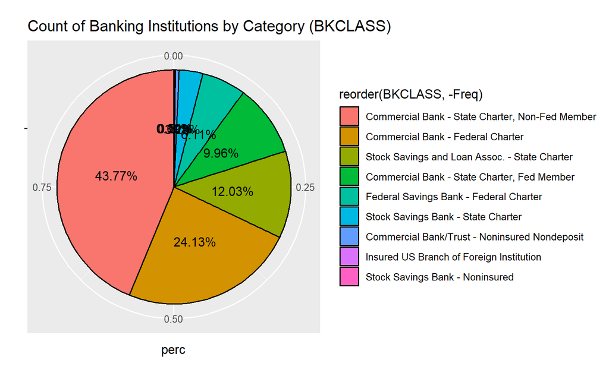

```r
bktab = data.frame(table(institutions$BKCLASS))
names(bktab)[names(bktab)=="Var1"] = "BKCLASS"
#bktab$perc = round(bktab$Freq/sum(bktab$Freq)*100,2)
bktab$perc = round(bktab$Freq/sum(bktab$Freq), 4)
bktab$perc2 = scales::percent(bktab$perc)
ggplot(bktab, aes(x="", y=perc, fill=reorder(BKCLASS,-Freq))) +
  geom_col() +
  coord_polar("y") +
  geom_bar(stat = "identity", color = "black") +
  geom_text(aes(label=perc2), position=position_stack(vjust=0.5)) +
  labs(title="Count of Banking Institutions by Category (BKCLASS)") +
  xlab("")
```

##### CLCODE

This one has a fairly large number of categories. The code chunk below just uses a factor variable for the numeric codes. I’ll leave the labeling for this one as an open issue that you can build out for some practice if you wish. The process should be nearly identical to the one for BKCLASS above, just with more categories to specify. If you build out a code chunk to do this, please send me a copy or push the updates to the GitHub repo.

From the Institutions Definitions file for the CLCODE variable:

“A two-digit identifying category of an institution. 03 = National bank, Federal Reserve System (FRS) member; 13 = State commercial bank, FRS member; 15 = State industrial bank, FRS member; 21 = State commercial bank, not FRS member; 23 = State industrial bank, not FRS member; 25 - State nonmember mutual bank; 33 = Federal chartered savings and co-operative bank - stock; 34 = Federal chartered savings and co-operative bank - mutual; 43 = Federal chartered stock savings bank (historical); 44 = Federal chartered mutual savings bank (historical); 35 = State chartered thrift - stock; 36 = State chartered thrift - mutual; 37 = Federal chartered thrift - stock; 38 = Federal chartered thrift - mutual; 41 = State chartered stock savings and co-operative bank; 42 = State chartered mutual savings and co-operative bank; 52 = Insured domestic offices of foreign banks (International Banking Act(IBA)); 50 = Nondeposit trust company, OCC chartered; 51 = Commercial bank; 52 = Noninsured domestic offices of foreign bank (IBA); 53 = Industrial bank; 54 = Nondeposit trust company, state chartered, not FRS member; 57 = New York investment company; 58 = Nondeposit trust company, state chartered, FRS member; 59 = Nondeposit trust company; 61 = Noninsured private bank; 62 = Noninsured loan workout bank, OCC chartered; 63 = Noninsured loan workout bank, state chartered, FRS member; 64 = Noninsured loan workout bank, state chartered, not FRS member; 81 = Noninsured stock savings and co-operative bank; 82 = Noninsured mutual savings and co-operative bank; 85 = Noninsured stock savings and loan association; 86 = Noninsured mutual savings and loan association; 89 = Noninsured insurance company.”

```r
institutions$CLCODE = as.factor(institutions$CLCODE)
```

##### FDICDBS

*Note: the definition below has eight FDIC regions; however, the data appears to only contain six categories (2, 5, 9, 11, 13, and 14). Using the FDICREGN variable, we can manually match these to the codes as in the chunk below.*

From the Institutions Definitions file for the FDICDBS variable:

“The FDIC Office assigned to the geographic area. The eight FDIC Regions and their respective states are:

- Boston - Connecticut, Maine, Massachusetts, New Hampshire, Rhode Island, Vermont
- New York - Delaware, District of Columbia, Maryland, New Jersey, New York, Pennsylvania, Puerto Rico, U.S. Virgin Islands
- Atlanta - Alabama, Florida, Georgia, North Carolina, South Carolina, Virginia, West Virginia
- Memphis - Arkansas, Kentucky, Louisiana, Mississippi, Tennessee
- Chicago - Illinois, Indiana, Michigan, Ohio, Wisconsin
- Kansas City - Iowa, Kansas, Minnesota, Missouri, Nebraska, North Dakota, South Dakota
- Dallas - Colorado, New Mexico, Oklahoma, Texas
- San Francisco - Alaska, American Samoa, Arizona, California, Guam, Hawaii, Idaho, Montana, Nevada, Oregon, States of Micronesia, Utah, Washington, Wyoming”

```r
table(institutions$FDICDBS)
```

```
   2    5    9   11   13   14
4056 4658 5521 4576 6239 2774
```

```r
institutions$FDICDBS = factor(institutions$FDICDBS,
                                levels=c('2','5','9','11','13','14'),
                                labels = c('New York',
                                           'Atlanta',
                                           'Chicago',
                                           'Kansas City',
                                           'Dallas',
                                           'San Francisco'))

table(institutions$FDICDBS)
```

```
     New York       Atlanta       Chicago   Kansas City        Dallas San Francisco
         4056          4658          5521          4576          6239          2774
```

If we cross-tabulate this factor variable with the `FDICREGN` variable, we can see that they are now identical in regard to the categories. So we can actually just remove one of the variables to prevent storing redundant data. I think `FDICREGN` is a more intuitive variable name, so let’s remove the `FDICDBS` variable.

```r
table(institutions$FDICDBS,institutions$FDICREGN)
```

```
                Atlanta Chicago Dallas Kansas City New York San Francisco
  New York            0       0      0           0     4056             0
  Atlanta          4658       0      0           0        0             0
  Chicago             0    5521      0           0        0             0
  Kansas City         0       0      0        4576        0             0
  Dallas              0       0   6239           0        0             0
  San Francisco       0       0      0           0        0          2774
```

```r
institutions = select(institutions,-FDICDBS)
```

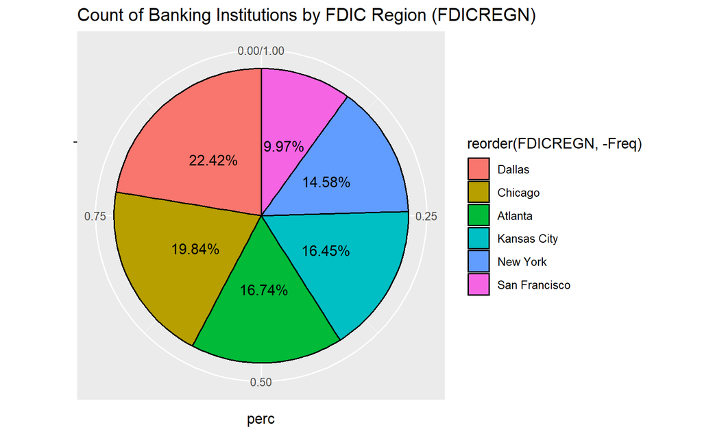

```r
fdictab = data.frame(table(institutions$FDICREGN))
names(fdictab)[names(fdictab)=="Var1"] = "FDICREGN"
fdictab$perc = round(fdictab$Freq/sum(fdictab$Freq), 4)
fdictab$perc2 = scales::percent(fdictab$perc)
ggplot(fdictab, aes(x="", y=perc, fill=reorder(FDICREGN,-Freq))) +
  geom_col() +
  coord_polar("y") +
  geom_bar(stat = "identity", color = "black") +
  geom_text(aes(label=perc2), position=position_stack(vjust=0.5)) +
  labs(title="Count of Banking Institutions by FDIC Region (FDICREGN)") +
  xlab("")
```

##### FED

From the Institutions Definitions file for the FDICDBS variable:

“A number used to identify the Federal Reserve district in which the institution is located.

- 01 Boston
- 02 New York
- 03 Philadelphia
- 04 Cleveland
- 05 Richmond
- 06 Atlanta
- 07 Chicago
- 08 St. Louis
- 09 Minneapolis
- 10 Kansas city
- 11 Dallas
- 12 San Francisco”

```r
table(institutions$FED)
```

```
   1    2    3    4    5    6    7    8    9   10   11   12
1104 1354  989 1532 1988 4029 4055 2151 1778 3392 3042 2410
```

```r
institutions$FED = factor(institutions$FED,
                                levels=c('1','2','3','4','5','6','7','8','9','10','11','12'),
                                labels = c('Boston', 'New York','Philadelphia','Cleveland','Richmond','Atlanta','Chicago','St. Louis','Minneapolis','Kansas City','Dallas','San Francisco'))
table(institutions$FED)
```

```
       Boston      New York  Philadelphia     Cleveland      Richmond       Atlanta       Chicago
         1104          1354           989          1532          1988          4029          4055
    St. Louis   Minneapolis   Kansas City        Dallas San Francisco
         2151          1778          3392          3042          2410
```

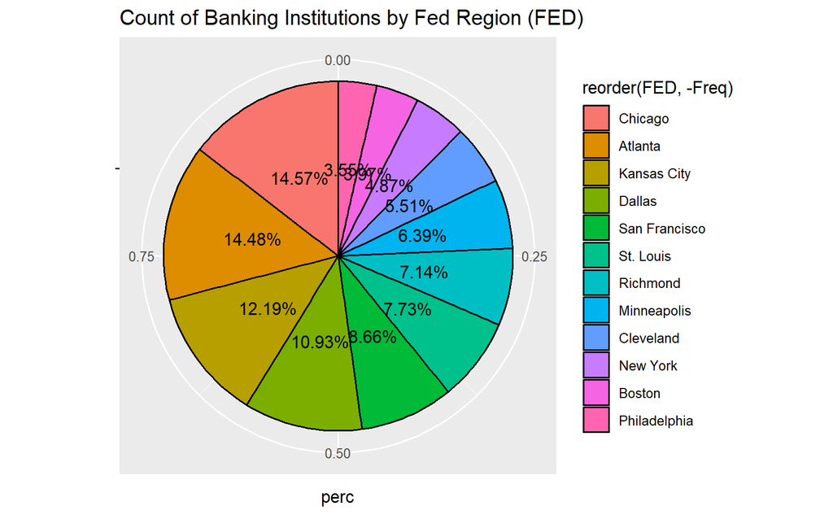

```r
fedtab = data.frame(table(institutions$FED))
names(fedtab)[names(fedtab)=="Var1"] = "FED"
fedtab$perc = round(fedtab$Freq/sum(fedtab$Freq), 4)
fedtab$perc2 = scales::percent(fedtab$perc)
ggplot(fedtab, aes(x="", y=perc, fill=reorder(FED,-Freq))) +
  geom_col() +
  coord_polar("y") +
  geom_bar(stat = "identity", color = "black") +
  geom_text(aes(label=perc2), position=position_stack(vjust=0.5)) +
  labs(title="Count of Banking Institutions by Fed Region (FED)") +
  xlab("")
```

##### OTSDIST/OTSREGNM

From the definitions below, we can see that these variables pertain to data that is mostly no longer relevant. However, the cleaning for this variable can be good practice since there is a typo in one of the observations for OTSREGNM

From the Institutions Definitions file for the OTSDIST variable:

“Office of Thrift Supervision (OTS) District - No longer used as of 7/21/11”

From the Institutions Definitions file for the OTSDIST variable:

“Prior to 7/21/11, the Office of Thrift Supervision (OTS) Region in which the institution is physically located. The five OTS Regions and their respective states are:

- Northeast - Connecticut, Delaware, Maine, Massachusetts, New Hampshire, New Jersey, New York, Pennsylvania, Rhode Island, Vermont, West Virginia
- Southeast - Alabama, District of Columbia, Florida, Georgia, Maryland, North Carolina, Puerto Rico, South Carolina, U.S. Virgin Islands, Virginia
- Central - Illinois, Indiana, Kentucky, Michigan, Ohio, Tennessee, Wisconsin
- Midwest - Arkansas, Colorado, Iowa, Kansas, Louisiana, Minnesota, Mississippi, Missouri, Nebraska, New Mexico, North Dakota, Oklahoma, South Dakota, Texas
- West - Alaska, American Samoa, Arizona, California, Guam, Hawaii, Idaho, Montana, Nevada, States of Micronesia, Oregon, Utah, Washington, Wyoming”

From the cross-tabulation below, we can see the typo in a single observation for OTSREGNM. Similarly, the labels show a West and Western, rather than Midwest and West. To verify which corresponds to each numeric code in OTSDIST, open the table and look at some examples in each category. That should clarify that the “Western” label refers to the Midwest category. So we’ll correct this labeling when reformating the numeric categories of OTSDIST to a factor variable. Then we can remove the OTSREGNM variable since it is just redundant and still has the typo.

```r
table(institutions$OTSDIST,institutions$OTSREGNM)
```

```
    Central Northeast Southeast West Western Wewst
  1       0      3938         0    0       0     0
  2       0         0      5931    0       0     0
  3    4972         0         0    0       0     0
  4       0         0         0    0    4875     0
  5       0         0         0 8106       0     1
```

```r
institutions$OTSDIST = factor(institutions$OTSDIST,
                                levels=c('1','2','3','4','5'),
                                labels = c('Northeast',
                                           'Southeast',
                                           'Central',
                                           'Midwest',
                                           'West'))

table(institutions$OTSDIST)
```

```
Northeast Southeast   Central   Midwest      West
     3938      5931      4972      4875      8107
```

```r
#rm(institutions$OTSREGNM)
```

## Final Comparisons

```r
dir.create("Data/Clean/", showWarnings=FALSE)
write.csv(institutions,"Data/Clean/institutions.csv")
saveRDS(institutions,"Data/Clean/institutions.Rds")
write.fst(institutions,"Data/Clean/institutions.fst")
file.size("Data/Raw/institutions.csv")
```

```
[1] 23167190
```

```r
file.size("Data/Clean/institutions.csv")
```

```
[1] 25850500
```

```r
file.size("Data/Clean/institutions.csv")/file.size("Data/Raw/institutions.csv")
```

```
[1] 1.115824
```

```r
file.size("Data/Raw/institutions.Rds")
```

```
[1] 4515005
```

```r
file.size("Data/Clean/institutions.Rds")
```

```
[1] 4293612
```

```r
file.size("Data/Clean/institutions.Rds")/file.size("Data/Raw/institutions.Rds")
```

```
[1] 0.9509651
```

```r
file.size("Data/Raw/institutions.fst")
```

```
[1] 14670970
```

```r
file.size("Data/Clean/institutions.fst")
```

```
[1] 12626667
```

```r
file.size("Data/Clean/institutions.fst")/file.size("Data/Raw/institutions.fst")
```

```
[1] 0.8606566
```

Then as a final comparison between the data storage formats, let’s see how long it takes to load each of the cleaned datasets. Here, we can see that the csv is the slowest (and also loses much of the formatting that we did). Then from the Rds vs. fst comparison, we can see that the fst version of the data loads into memory faster than Rds. However, given the small size of the files, the marginally faster load time may not be worth the additional storage space. This tradeoff between speed and size can persist to larger datasets, and the preferred option is likely to be different for various applications and datasets.

```r
# Time to Load csv data
t = proc.time()
inst = read_csv("Data/Clean/institutions.csv")
```

[output not shown]

```r
proc.time() - t
```

```
   user  system elapsed
   0.28    0.01    0.61
```

```r
rm(inst)
# Time to Load csv data
t = proc.time()
inst = readRDS("Data/Clean/institutions.Rds")
proc.time() - t
```

```
   user  system elapsed
   0.35    0.04    0.42
```

```r
rm(inst)
# Time to Load csv data
t = proc.time()
inst = read.fst("Data/Clean/institutions.fst")
proc.time() - t
```

```
   user  system elapsed
   0.01    0.02    0.12
```

```r
rm(inst)
```

### The Consolidation of the Banking Industry

ACTIVE - A number indicating the status of an institution. 1=‘Institutions that are currently open and insured by the FDIC’; 0=‘Institution closed or not insured by FDIC’

ENDEFYMD - The date that ends or closes out the last structural event relating to an institution. For closed institutions, this date represents the day that the institution became inactive.

ESTYMD - The date on which the institution or branch began operations.

#### ChatGPT for Initiating Time Series

To aid with the problem-solving aspect of generating our time series of active banking institutions, let’s explore the use of ChatGPT to help build this out.

The following code chunk is directly from ChatGPT’s (Mar 23, 2023, version) response to the following prompt: “If i have a start date and end date, how can i use those to create a monthly xts object in R?” The response is commented out since I need to do some adaptation to (1) actually get the code to run in our current environment and (2) adapting the code to my preferred coding style.

```r
# library(xts)
#
# # Set start and end dates
# start_date <- as.Date("2022-01-01")
# end_date <- as.Date("2023-03-31")
#
# # Create a sequence of dates by month
# monthly_dates <- seq(start_date, end_date, by = "month")
#
# # Create an empty xts object with monthly dates
# monthly_xts <- xts(rep(NA, length(monthly_dates)), monthly_dates)
#
# # Fill in the xts object with your data values
# monthly_xts[time(monthly_xts) %in% time(data_values)] <- data_values
#
# # Aggregate the xts object by month
# monthly_xts <- apply.monthly(monthly_xts, sum)
#
# # View the resulting monthly xts object
# monthly_xts
```

And now my adaptation of the above code to fit our dataset:

```r
# Set start and end dates
start_date = min(institutions$ESTYMD)
end_date = as.Date(Sys.Date())

# Create a sequence of dates by month
monthly_dates = seq(start_date, end_date, by="month")

# Create an empty xts object with monthly dates
df = data.frame(t=-length(monthly_dates):-1,
                n_estab_all=rep(NA,length(monthly_dates),1),
                n_close_all=rep(NA,length(monthly_dates),1),
                n_estab_state = rep(NA,length(monthly_dates),1),
                n_close_state = rep(NA,length(monthly_dates),1))
monthly_xts = xts(df, order.by=monthly_dates)
```

#### Loop through time to count active institutions

```r
for (i in 1:length(monthly_xts$t)) {
  t = monthly_dates[i]
  monthly_xts$nesty[i] = sum(institutions$ESTYMD<t)
  monthly_xts$nclosed[i] = sum(institutions$INACTIVE & institutions$ENDEFYMD<t)
}
```

```r
monthly_xts$nactive = as.double(monthly_xts$nesty)-as.double(monthly_xts$nclosed)
```

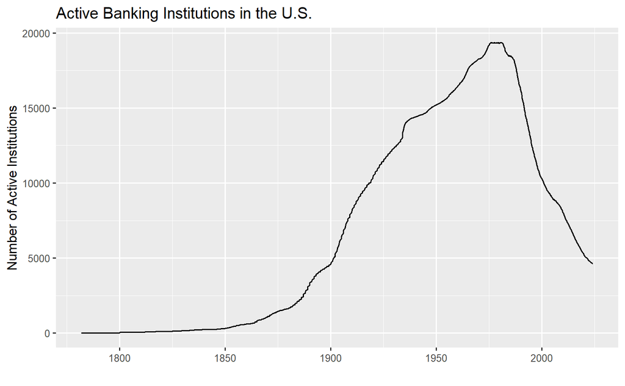

```r
ggplot(monthly_xts,aes(x=index(monthly_xts),y=nactive)) +
  geom_line() +
  ggtitle("Active Banking Institutions in the U.S.") +
  xlab("") +
  ylab("Number of Active Institutions")
```